# Homework 2: Mapping Severe Weather Events

Data Visualization

Jenna Swartz

2024-03-11

# Preparation

```r
options(repos = 'https://cran.rstudio.com/')  # Set CRAN mirror
install.packages("maps")
library(maps)
library(dplyr)
library(tidyverse)
library(ggplot2)
install.packages("ggthemes")
library(ggthemes)
install.packages("remotes")
remotes::install_github("UrbanInstitute/urbnmapr")
library(urbnmapr)
library(sf)
library(leaflet)
library(RColorBrewer)
install.packages("geosphere")
library(geosphere)
#Loading in storm data
file_path <- "C:/Users/jenna/Documents/Data Viz/course materials/course_content/Exercises/07_severe_weather_GRADED/data/storms.csv"
storm_data <- read_csv(file_path)
```

# PART 1: Damage From Storms

## a) State Level Choropleth Maps

```r
# Using maps package, which has geographic information on all U.S states
us.states <- map_data("state") %>%
  as_tibble(.) %>%
  dplyr::rename(state = region) %>%
  select(-subregion) %>%
  mutate(state = str_to_title(state))

# Add State Abbreviations and Centers
statenames <- as_tibble(
  cbind(state=state.name, state.abb = state.abb,
        state.center.x = state.center$x,
        state.center.y = state.center$y))
statenames #has state, state.abb, state.center.x and state.center.y
```

```
## # A tibble: 50 × 4
##    state       state.abb state.center.x state.center.y
##    <chr>       <chr>     <chr>          <chr>
##  1 Alabama     AL        -86.7509       32.5901
##  2 Alaska      AK        -127.25        49.25
##  3 Arizona     AZ        -111.625       34.2192
##  4 Arkansas    AR        -92.2992       34.7336
##  5 California  CA        -119.773       36.5341
##  6 Colorado    CO        -105.513       38.6777
##  7 Connecticut CT        -72.3573       41.5928
##  8 Delaware    DE        -74.9841       38.6777
##  9 Florida     FL        -81.685        27.8744
## 10 Georgia     GA        -83.3736       32.3329
## # ℹ 40 more rows
```

```r
statenames <- statenames %>% mutate_each_(funs(as.numeric), #changing centers to numeric
                                          vars=c("state.center.x","state.center.y"))
us.states <- left_join(us.states, statenames)
us.states #took us.states and added state abb state center x and y
```

```
## # A tibble: 15,537 × 8
##     long   lat group order state   state.abb state.center.x state.center.y
##    <dbl> <dbl> <dbl> <int> <chr>   <chr>              <dbl>          <dbl>
##  1 -87.5  30.4     1     1 Alabama AL                 -86.8           32.6
##  2 -87.5  30.4     1     2 Alabama AL                 -86.8           32.6
##  3 -87.5  30.4     1     3 Alabama AL                 -86.8           32.6
##  4 -87.5  30.3     1     4 Alabama AL                 -86.8           32.6
##  5 -87.6  30.3     1     5 Alabama AL                 -86.8           32.6
##  6 -87.6  30.3     1     6 Alabama AL                 -86.8           32.6
##  7 -87.6  30.3     1     7 Alabama AL                 -86.8           32.6
##  8 -87.6  30.3     1     8 Alabama AL                 -86.8           32.6
##  9 -87.7  30.3     1     9 Alabama AL                 -86.8           32.6
## 10 -87.8  30.3     1    10 Alabama AL                 -86.8           32.6
## # ℹ 15,527 more rows
```

```r
us.states <- us.states %>% #making title column all caps for easier merging
  rename(STATE = state)
us.states$STATE <- toupper(us.states$STATE) #making states all caps for easier merging

#now I will prepare a simple dataset with total money damage by state
storm_data_filtered <- select(storm_data, STATE, DAMAGE_PROPERTY_USD, DAMAGE_CROPS_USD)
storm_data_filtered <- storm_data_filtered %>%
  mutate(money_damage = DAMAGE_PROPERTY_USD + DAMAGE_CROPS_USD)
state_money_damages <- select(storm_data_filtered, -DAMAGE_PROPERTY_USD, -DAMAGE_CROPS_USD)

#merging sets
moneydamages.merged=left_join(state_money_damages, us.states, by='STATE')
moneydamages.merged
```

```
## # A tibble: 137,962,685 × 9
##    STATE      money_damage  long   lat group order state.abb state.center.x
##    <chr>             <dbl> <dbl> <dbl> <dbl> <int> <chr>              <dbl>
##  1 NEW JERSEY           NA -74.7  41.4    32  8765 NJ                 -74.2
##  2 NEW JERSEY           NA -74.4  41.2    32  8766 NJ                 -74.2
##  3 NEW JERSEY           NA -74.2  41.1    32  8767 NJ                 -74.2
##  4 NEW JERSEY           NA -74.2  41.1    32  8768 NJ                 -74.2
##  5 NEW JERSEY           NA -73.9  41.0    32  8769 NJ                 -74.2
##  6 NEW JERSEY           NA -73.9  40.9    32  8770 NJ                 -74.2
##  7 NEW JERSEY           NA -73.9  40.9    32  8771 NJ                 -74.2
##  8 NEW JERSEY           NA -73.9  40.9    32  8772 NJ                 -74.2
##  9 NEW JERSEY           NA -74.0  40.8    32  8773 NJ                 -74.2
## 10 NEW JERSEY           NA -74.0  40.8    32  8774 NJ                 -74.2
## # ℹ 137,962,675 more rows
## # ℹ 1 more variable: state.center.y <dbl>
```

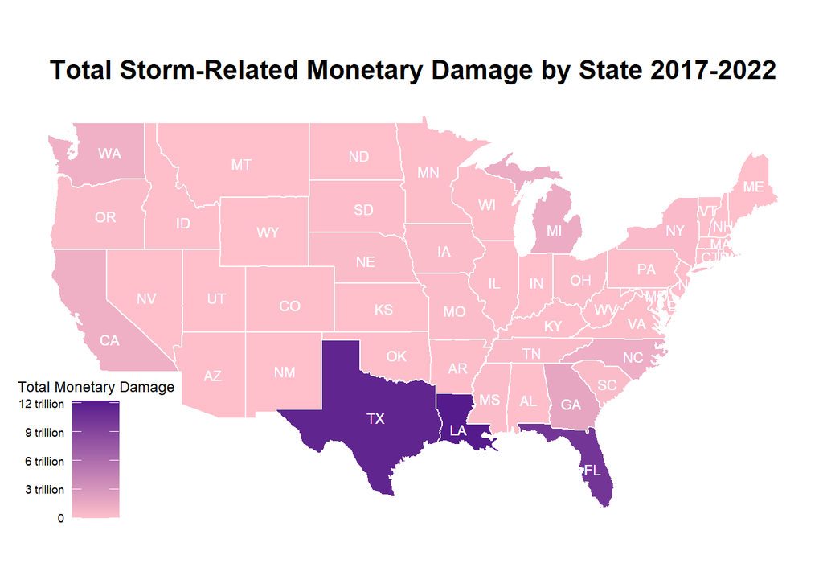

```r
# First, I will replace all NAs with zeros in the "money_damage" column
# Next, group by the "STATE" column and summarize the "money_damage" variable so we see sum of total $ damage
# for that state between 2017 and 2022, for all weather events combined.
moneydamages.merged <- moneydamages.merged %>%
  mutate(money_damage = replace_na(money_damage, 0))
summarized_statedamages <- moneydamages.merged %>%
  group_by(STATE) %>%
  summarise(total_money_damage = sum(money_damage))

#now I'll merge the total money damage for each state with state info from us.states
merged_final_statedamages = left_join(summarized_statedamages, us.states, by='STATE')

#Setting format for my labels so it'll show $ in million, billion, trillion, etc.in the legend
label_format <- function(x) {
  ifelse(x >= 1e12, paste0(format(x / 1e12, scientific = FALSE), " trillion"),
         ifelse(x >= 1e9, paste0(format(x / 1e9, scientific = FALSE), " billion"),
                ifelse(x >= 1e6, paste0(format(x / 1e6, scientific = FALSE), " million"),
                format(x, scientific = FALSE))))
}

# Creating a plot with darkest purple being most money spent and light pink being least money spent
ggplot(merged_final_statedamages,
       aes(x = long, y = lat, group = group, label = state.abb, fill = total_money_damage)) +
  geom_polygon(color = "white") +
  scale_fill_gradientn(colours = c("pink", "purple4"),
                       name = "Total Monetary Damage",
                       labels = label_format) +  # Using label formatting function
  ggtitle("Total Storm-Related Monetary Damage by State 2017-2022") +
  geom_text(aes(x = state.center.x, y = state.center.y, label = state.abb), color = "white", size = 3, inherit.aes = FALSE) +
  theme_map() +
  theme(
        text = element_text(family = "Times New Roman"),  # Change font to TNR
        plot.title = element_text(hjust = 0.5, size = 16, face = "bold")) +  # Centered title, size 16, bold
  coord_map(projection = "mercator") +
  guides(fill = guide_colorbar(barwidth = 2, barheight = 5,  # Adjust bar width and height
                               title.position = "top",
                               label.position = "left"))  # Adjust legend label position
```

## b) County Choropleth Maps

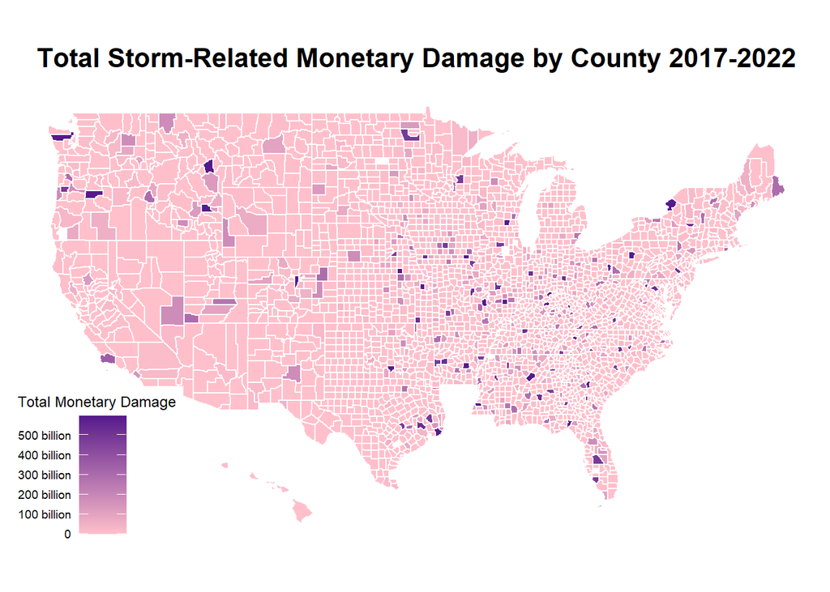

```r
#Starting by getting counties map and info
uscounties_sf <- get_urbn_map("counties", sf = TRUE)
# changing county fips column name in uscounties_sf for ease of merging later
colnames(counties)[colnames(counties) == "county_name"] <- "CZ_NAME"
counties$CZ_NAME <- toupper(counties$CZ_NAME)

#now preparing simple dataset with money damage by county (for each incident)
storm_data_counties <- filter(storm_data, CZ_TYPE == "C") #only grabbing events that happened in counties
storm_data_filtered2 <- select(storm_data_counties, CZ_NAME, DAMAGE_PROPERTY_USD, DAMAGE_CROPS_USD)
storm_data_filtered2 <- storm_data_filtered2 %>%
  mutate(money_damage2 = DAMAGE_PROPERTY_USD + DAMAGE_CROPS_USD)
county_money_damages <- select(storm_data_filtered2, -DAMAGE_PROPERTY_USD, -DAMAGE_CROPS_USD)
# adding "COUNTY" at ends of county names to prep for merging
county_money_damages$CZ_NAME <- paste(county_money_damages$CZ_NAME, "COUNTY", sep = " ")

# Now I will join the counties info
moneydamages.merged2 <- left_join(county_money_damages, counties, by = 'CZ_NAME')
# First, I will replace all NAs with zeros in the "money_damage2" column
#Next, I'll group by the "CZ_NAME" column and summarize the "money_damage2" variable so we see sum of total $
#damage for that county between 2017 and 2022 (combined from all the events)
moneydamages.merged2 <- moneydamages.merged2 %>%
  mutate(money_damage2 = replace_na(money_damage2, 0))
summarized_countydamages <- moneydamages.merged2 %>%
  group_by(CZ_NAME) %>%
  summarise(total_money_damage2 = sum(money_damage2))

#merging back total $ damages for each county with all the county info
merged_final_countydamages = left_join(summarized_countydamages, counties, by='CZ_NAME')

# Create the same plot as above but for counties. The darkest purple means most money spent and light pink means least money spent
ggplot(merged_final_countydamages,
       aes(x = long, y = lat, group = group, fill = total_money_damage2)) +
  geom_polygon(color = "white") +
  scale_fill_gradientn(colours = c("pink", "purple4"),
                       name = "Total Monetary Damage",
                       labels = label_format) +  # Use custom formatting function
  ggtitle("Total Storm-Related Monetary Damage by County 2017-2022") +
  theme_map() +
  theme(
    text = element_text(family = "Times New Roman"),  # Change font to TNR
    plot.title = element_text(hjust = 0.5, size = 16, face = "bold")) +  # Centered title, size 16, bold
  coord_map(projection = "mercator") +
  guides(fill = guide_colorbar(barwidth = 2, barheight = 5,  # Adjust bar width and height
                               title.position = "top",
                               label.position = "left"))  # Adjust legend label position
```

## c) Density Map

Below, I will map deaths associated with storms, creating a density map with each point representing a severe weather events that related in at least one death. The darker circles will represent more deaths caused by that storm and lighter circles with represent less deaths. I will combine both direct and indirect deaths to create a total deaths variable. I believe the county-level monetary damage map (part b above) creates the best visualization of the distribution of destructive effects of the storms. The density map I create below is helpful because it pinpoints each event that results in at least one death and gives us an idea of how deadly each of these events was. However, I did filter out all the incidents where there were no deaths, so this portrays only a fraction of the event data. The state map in part a is a little too broad but the counties map gives a comprehensive summary of monetary damage for smaller areas of land so it allows us to zoom in a bit more. It also seems monetary damage is more common than deaths so we are able to use more data in that map to get a picture of the variation between counties.

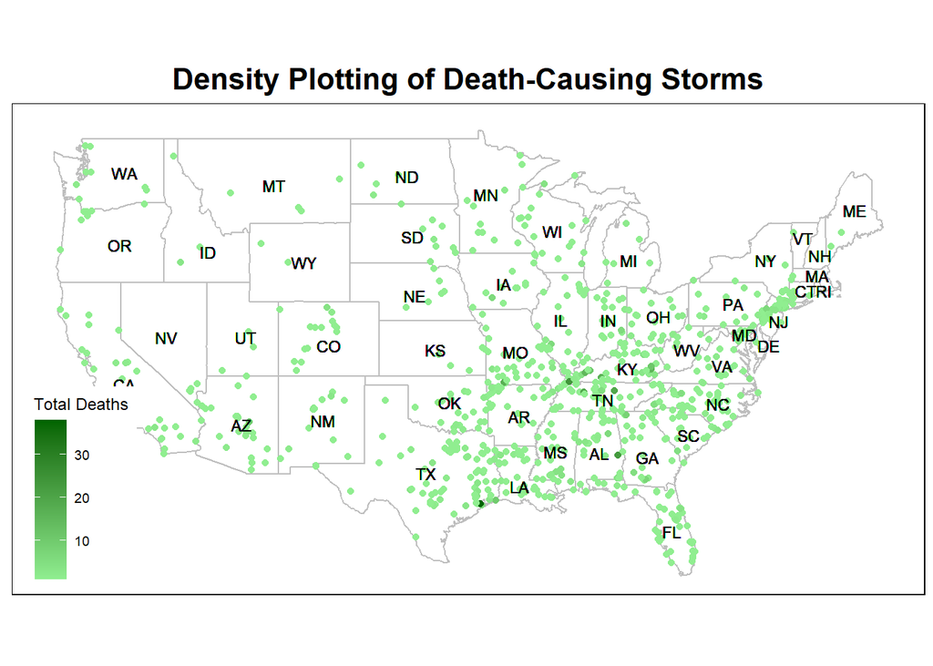

```r
#creating simple dataset with total deaths, lat and lon, state name
storm_data_filtered3 <- mutate(storm_data, total_deaths = DEATHS_DIRECT + DEATHS_INDIRECT)
storm_data_filtered3 <- select(storm_data_filtered3, BEGIN_LAT, BEGIN_LON, total_deaths, STATE)

# Filter out rows with missing latitude or longitude values and where there were zero deaths
storm_data_filtered3 <- storm_data_filtered3[complete.cases(storm_data_filtered3$BEGIN_LAT, storm_data_filtered3$BEGIN_LON), ]
storm_data_filtered3 <- filter(storm_data_filtered3, total_deaths != 0)


#I am only going to plot deaths on my map (in continental U.S.) So, I define the values I want to filter out
#(those not on map of continental US aka filtering out non-first-48 states)
states_to_exclude <- c("PUERTO RICO", "ATLANTIC SOUTH", "ATLANTIC NORTH", "GULF OF MEXICO", "LAKE MICHIGAN", "ALASKA", "HAWAII", "GUAM", "LAKE ERIE")

# Filter out rows where the "state" column equals the specified states to exclude
storm_data_filtered3_continental <- filter(storm_data_filtered3, !(STATE %in% states_to_exclude))

# Load state map data
us.states <- map_data("state")

# Create the plot with state boundaries and storm data points
ggplot() +
  geom_polygon(data = us.states, aes(x = long, y = lat, group = group), color = "grey", fill = "white") +
  geom_point(data = storm_data_filtered3_continental, aes(x = BEGIN_LON, y = BEGIN_LAT, color = total_deaths)) +
  geom_text(data = merged_final_statedamages, aes(x = state.center.x, y = state.center.y, label = state.abb), color = "black", size = 3) +
  scale_color_gradient(low = "lightgreen", high = "darkgreen", name = "Total Deaths") +
  ggtitle("Density Plotting of Death-Causing Storms") +
  theme_map() +
  theme(
    text = element_text(family = "Times New Roman"),  # Change font to TNR
    plot.title = element_text(hjust = 0.5, size = 16, face = "bold"),
    panel.background = element_rect(fill = "white"),  # Set background color to white
    panel.border = element_blank(),  # Remove panel border
    panel.grid.major = element_blank(),  # Remove major gridlines
    panel.grid.minor = element_blank(),  # Remove minor gridlines
    legend.position = c(0.015, 0.015)) +  # Adjust legend position (x, y)
  coord_map(projection = "mercator") +
  guides(fill = guide_colorbar(barwidth = 2, barheight = 5,  # Adjust bar width and height
                               title.position = "top",
                               label.position = "left"))  # Adjust legend label position
```

# PART 2: Location of Severe Events

## a) Interactive Map of Severe Weather Events

```r
#I'm going to alter the original dataset so that I'm only looking at the continental US (first 48 states)
#and also so I only include the incidents that resulted in a death

#first combine direct and indirect deaths
storm_data_alldeathscombined <- mutate(storm_data, total_deaths = DEATHS_DIRECT + DEATHS_INDIRECT)
#now only keeping rows where total death is not zero and getting rid of any rows with missing lat/lon
storm_data_deathsonly <- filter(storm_data_alldeathscombined, total_deaths != 0)
storm_data_deathsonly <- storm_data_deathsonly[complete.cases(storm_data_deathsonly$BEGIN_LAT, storm_data_deathsonly$BEGIN_LON), ]
#now only keeping incidents that happened in continental US (first 48 states)
storm_data_deathsonly_continental <- filter(storm_data_deathsonly, !(STATE %in% states_to_exclude))

#establishing popup content
popup_content <- paste("Type:",storm_data_deathsonly_continental$EVENT_TYPE,"<br/>",
                 "When:",storm_data_deathsonly_continental$MONTH_NAME," ",storm_data_deathsonly_continental$YEAR,"<br/>",
                 "State:",storm_data_deathsonly_continental$STATE,"<br/>",
                 "# of Deaths:",storm_data_deathsonly_continental$total_deaths,"<br/>")

# Defining a function to calculate radius based on zoom level
zoomToRadius <- function(zoom) {
  # Adjusting the multiplier as needed to control the rate of increase in radius with zoom
  base_radius <- 50000
  radius <- base_radius / zoom
  return(radius)
}

#Using leaflet to add dots where there was at least one death, adding popup option
m <- leaflet(storm_data_deathsonly_continental) %>%
  addTiles('http://{s}.basemaps.cartocdn.com/light_all/{z}/{x}/{y}.png') %>%
  addCircles(lng = ~BEGIN_LON, lat = ~BEGIN_LAT, col = "orange", radius = zoomToRadius(10), popup = popup_content)
m
```

[interactive chart not shown]

## b) Color by Type of Weather Event

```r
unique(storm_data_deathsonly_continental$EVENT_TYPE) #checking the storm types
```

```
## [1] "Flood"              "Thunderstorm Wind"  "Tornado"
## [4] "Heavy Rain"         "Hail"               "Flash Flood"
## [7] "Lightning"          "Debris Flow"        "Marine Strong Wind"
```

```r
#let's combine flood/flash flood into a category, Hail/Heavy Rain, Thunderstorm Wind/Lightning/Marine Strong Wind,
#and keep Tornado and Debris Flow separate
target_flood <- c("Flood", "Flash Flood")
storm_data_deathsonly_continental <- mutate(storm_data_deathsonly_continental,
                     EVENT_TYPE = ifelse(EVENT_TYPE %in% target_flood,
                                         "Flood or Flash Flood",
                                         EVENT_TYPE))
target_heavyrain <- c("Hail", "Heavy Rain")
storm_data_deathsonly_continental <- mutate(storm_data_deathsonly_continental,
                                            EVENT_TYPE = ifelse(EVENT_TYPE %in% target_heavyrain,
                                                                "Hail or Heavy Rain",
                                                                EVENT_TYPE))
target_windthunlight <- c("Thunderstorm Wind", "Lightning", "Marine Strong Wind")
storm_data_deathsonly_continental <- mutate(storm_data_deathsonly_continental,
                                            EVENT_TYPE = ifelse(EVENT_TYPE %in% target_windthunlight,
                                                                "Lightning, Thunderstorm Wind or Marine Strong Wind",
                                                                EVENT_TYPE))
#making sure we have 5 distinct categories of events now
unique(storm_data_deathsonly_continental$EVENT_TYPE)
```

```
## [1] "Flood or Flash Flood"
## [2] "Lightning, Thunderstorm Wind or Marine Strong Wind"
## [3] "Tornado"
## [4] "Hail or Heavy Rain"
## [5] "Debris Flow"
```

```r
#now preparing to add color
pal = colorFactor("Set1", domain = storm_data_deathsonly_continental$EVENT_TYPE) # Grab a palette
color_EVENT_TYPE = pal(storm_data_deathsonly_continental$EVENT_TYPE)

m2 <- leaflet(storm_data_deathsonly_continental) %>%
  addTiles('http://{s}.basemaps.cartocdn.com/light_all/{z}/{x}/{y}.png') %>%
  addCircles(lng = ~BEGIN_LON, lat = ~BEGIN_LAT, col = color_EVENT_TYPE, radius = zoomToRadius(10), popup = popup_content) %>%
  addLegend(pal = pal, values = ~storm_data_deathsonly_continental$EVENT_TYPE, title = "Type of Death-Causing Event")
m2
```

[interactive chart not shown]

## c) Clustering

```r
# Add marker clustering
m3 <- leaflet(storm_data_deathsonly_continental) %>%
  addTiles('http://{s}.basemaps.cartocdn.com/light_all/{z}/{x}/{y}.png') %>%
  addCircles(lng = ~BEGIN_LON, lat = ~BEGIN_LAT, col = color_EVENT_TYPE, radius = zoomToRadius(10), popup = popup_content) %>%
  addMarkers(data = storm_data_deathsonly_continental, lng = ~BEGIN_LON, lat = ~BEGIN_LAT, clusterOptions = markerClusterOptions())
m3
```

[interactive chart not shown]

# PART 3: Severe Events and Cities

```r
install.packages("RANN")
library(RANN)
#Bringing in cities data
file_path2 <- "C:/Users/jenna/Downloads/us-cities-top-1k.csv"
cities_data <- read_csv(file_path2)
head(cities_data)
```

```
## # A tibble: 6 × 5
##   City       State          Population   lat    lon
##   <chr>      <chr>               <dbl> <dbl>  <dbl>
## 1 Marysville Washington          63269  48.1 -122.
## 2 Perris     California          72326  33.8 -117.
## 3 Cleveland  Ohio               390113  41.5  -81.7
## 4 Worcester  Massachusetts      182544  42.3  -71.8
## 5 Columbia   South Carolina     133358  34.0  -81.0
## 6 Waterbury  Connecticut        109676  41.6  -73.1
```

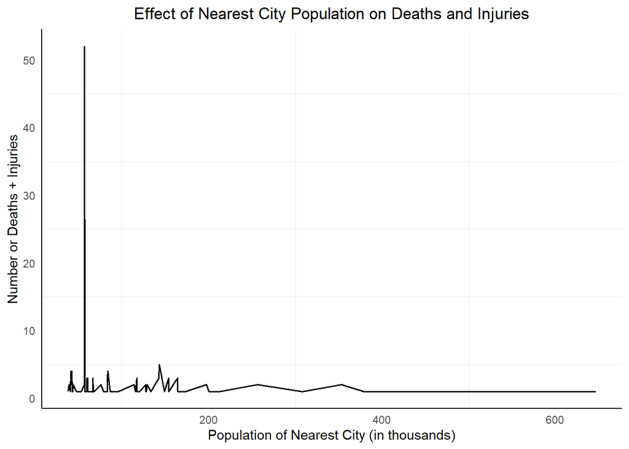

```r
# Creating a function to calculate distance between any two points using geosphere::distGeo()
calculate_distance <- function(lat1, lon1, lat2, lon2) {
  dist <- distGeo(matrix(c(lon1, lat1), ncol = 2), matrix(c(lon2, lat2), ncol = 2))
  return(dist)
}

#let's create continental only set:
#first combine direct and indirect deaths
#storm_data_alldeathscombined <- mutate(storm_data, total_deaths = DEATHS_DIRECT + DEATHS_INDIRECT)
#now only keeping rows where total death is not zero and getting rid of any rows with missing lat/lon
#storm_data_deathsonly <- filter(storm_data_alldeathscombined, total_deaths != 0)
storm_data_continentalonly <- storm_data[complete.cases(storm_data$BEGIN_LAT, storm_data$BEGIN_LON), ]
#now only keeping incidents that happened in continental US (first 48 states)
storm_data_continentalonly <- filter(storm_data_continentalonly, !(STATE %in% states_to_exclude))

#When I was using my below distance-calculating algorithm, it was taking a really long time. So I'm just
#going to look at the first 10,000 storm entries for this question.
storm_data_subset <- storm_data_continentalonly[1:10000,]

# Iterate through each weather event in the subset and find the nearest city
for (i in 1:nrow(storm_data_subset)) {
  storm_lat <- storm_data_subset[i, "BEGIN_LAT"]
  storm_lon <- storm_data_subset[i, "BEGIN_LON"]

  # Calculate distances to all cities
  city_coords <- cities_data[, c("lat", "lon")]
  nn_result <- nn2(city_coords, matrix(c(storm_lat, storm_lon), ncol = 2), k = 1)

  # Get the index of the nearest city
  nearest_city_index <- nn_result$nn.idx

  # Get the distance to the nearest city
  nearest_city_distance <- nn_result$nn.dists

  # Assign the nearest city and its distance to the dataset
  storm_data_subset[i, "nearest_city"] <- cities_data$City[nearest_city_index]
  storm_data_subset[i, "distance_to_nearest_city"] <- nearest_city_distance
}



#Now lets add in population corresponding to each nearest city

# Clean city names in storm_data_subset before merging
storm_data_subset$clean_nearest_city <- tolower(trimws(storm_data_subset$nearest_city))

cities_data$clean_city <- tolower(trimws(cities_data$City))

# Merge storm_data_subset with cities_data based on clean_city
merged_data <- merge(storm_data_subset, cities_data, by.x = "clean_nearest_city", by.y = "clean_city", all.x = TRUE)

#Now, I'm good to go with my merged data
#This time I'll look at all the deaths and injuries combined resulting from each event

merged_data$alldeathsinjuries <- merged_data$DEATHS_INDIRECT + merged_data$DEATHS_DIRECT + merged_data$INJURIES_DIRECT + merged_data$INJURIES_INDIRECT
#let's get entries where there is at least one death or injury
merged_data_deaths_injuries_nonzero <- filter(merged_data, alldeathsinjuries != 0)

#PLOT
# Plot the merged data in one graph - again this is just using the first 10,000 from the original storm data
ggplot(data = merged_data_deaths_injuries_nonzero, aes(x = Population, y = alldeathsinjuries)) +
  geom_line(linewidth = .7) +
  labs(x = "Population of Nearest City (in thousands)", y = "Number or Deaths + Injuries") +  # Reme titles
  theme_minimal() +  #Apply minimal theme
  ggtitle("Effect of Nearest City Population on Deaths and Injuries") +
  theme(plot.title = element_text(hjust = 0.5)) +
  theme(
    panel.grid.major = element_blank(),  # Remove major gridlines
    axis.line = element_line(color = "black"),  # Set axis line color
    legend.position = "top",  # Position legend at the top
    legend.title = element_text(size = 10),  # Set legend title size
    legend.text = element_text(size = 8)  # Set legend text size
  ) +
  scale_x_continuous(labels = scales::comma_format(scale = 1e-3))
```

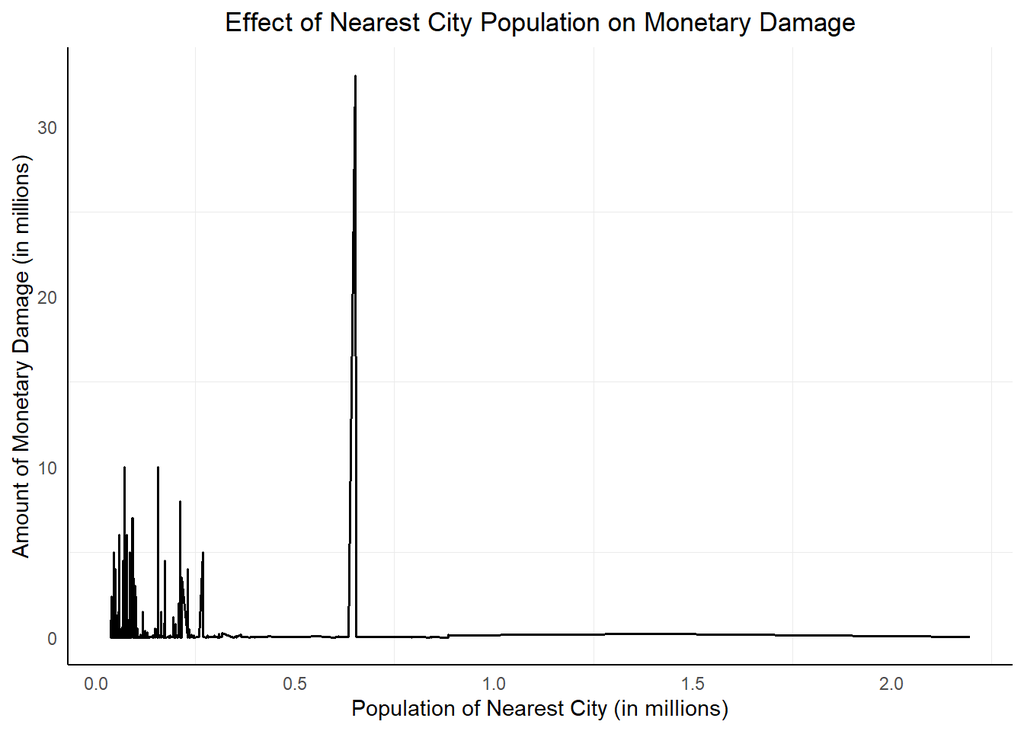

```r
#Let's do the same thing but with money damage from each event this time
merged_data$allmoneydamage <- merged_data$DAMAGE_PROPERTY_USD + merged_data$DAMAGE_CROPS_USD
merged_data <- merged_data %>%
  mutate(allmoneydamage = replace_na(allmoneydamage, 0))
#let's take out events where there was no money damage
merged_data_money_damage_nonzero <- filter(merged_data, allmoneydamage != 0)

#PLOT
ggplot(data = merged_data_money_damage_nonzero, aes(x = Population, y = allmoneydamage)) +
  geom_line(linewidth = .7) +
  labs(x = "Population of Nearest City (in millions)", y = "Amount of Monetary Damage (in millions)") +
  theme_minimal() +  #Apply minimal theme
  ggtitle("Effect of Nearest City Population on Monetary Damage") +
  theme(plot.title = element_text(hjust = 0.5)) +
  theme(
    panel.grid.major = element_blank(),  # Remove major gridlines
    axis.line = element_line(color = "black"),  # Set axis line color
    legend.position = "top",  # Position legend at the top
    legend.title = element_text(size = 10),  # Set legend title size
    legend.text = element_text(size = 8)  # Set legend text size
  ) +
  scale_x_continuous(labels = scales::comma_format(scale = 1e-6)) +
  scale_y_continuous(labels = scales::comma_format(scale = 1e-6))
```

```r
#Let's check out the money damage effects by event type
unique(merged_data_money_damage_nonzero$EVENT_TYPE)
```

```
## [1] "Thunderstorm Wind" "Flash Flood"       "Hail"
## [4] "Flood"             "Tornado"           "Lightning"
## [7] "Debris Flow"       "Heavy Rain"        "Dust Devil"
```

```r
#Setting my collapsed categories
target_flood_rain_hail <- c("Flood", "Flash Flood", "Heavy Rain", "Hail")
merged_data_money_damage_nonzero <- mutate(merged_data_money_damage_nonzero,
                                            EVENT_TYPE = ifelse(EVENT_TYPE %in% target_flood_rain_hail,
                                                                "Flood, Rain or Hail",
                                                                EVENT_TYPE))
#anything mentioning wind or dust or tornado
target_tornado_wind <- c("Tornado", "Thunderstorm Wind", "Dust Devil", "Marine Thunderstorm Wind", "Marine High Wind")
merged_data_money_damage_nonzero <- mutate(merged_data_money_damage_nonzero,
                                            EVENT_TYPE = ifelse(EVENT_TYPE %in% target_tornado_wind,
                                                                "Wind, Dust, Tornado",
                                                                EVENT_TYPE))

#everything else
target_misc <- c("Funnel Cloud", "Lightning", "Debris Flow", "Waterspout")
merged_data_money_damage_nonzero <- mutate(merged_data_money_damage_nonzero,
                      EVENT_TYPE = ifelse(EVENT_TYPE %in% target_misc,
                                          "Other",
                                          EVENT_TYPE))

#making sure we have 5 distinct categories of events now
unique(merged_data_money_damage_nonzero$EVENT_TYPE)
```

```
## [1] "Wind, Dust, Tornado" "Flood, Rain or Hail" "Other"
```

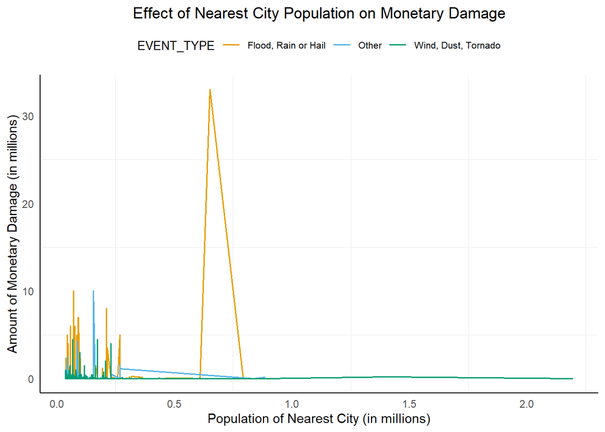

```r
#PLOT
# Plot the merged data in one graph
ggplot(data = merged_data_money_damage_nonzero, aes(x = Population, y = allmoneydamage, color = EVENT_TYPE)) +
  geom_line(linewidth = .7) +
  scale_color_manual(values = c("#E69F00", "#56B4E9", "#009E73")) +
  labs(x = "Population of Nearest City (in millions)", y = "Amount of Monetary Damage (in millions)") +  # Reme titles
  theme_minimal() +  #Apply minimal theme
  ggtitle("Effect of Nearest City Population on Monetary Damage") +
  theme(plot.title = element_text(hjust = 0.5)) +
  theme(
    panel.grid.major = element_blank(),  # Remove major gridlines
    axis.line = element_line(color = "black"),  # Set axis line color
    legend.position = "top",  # Position legend at the top
    legend.title = element_text(size = 10),  # Set legend title size
    legend.text = element_text(size = 8)  # Set legend text size
  ) +
  scale_x_continuous(labels = scales::comma_format(scale = 1e-6)) +
  scale_y_continuous(labels = scales::comma_format(scale = 1e-6))
```

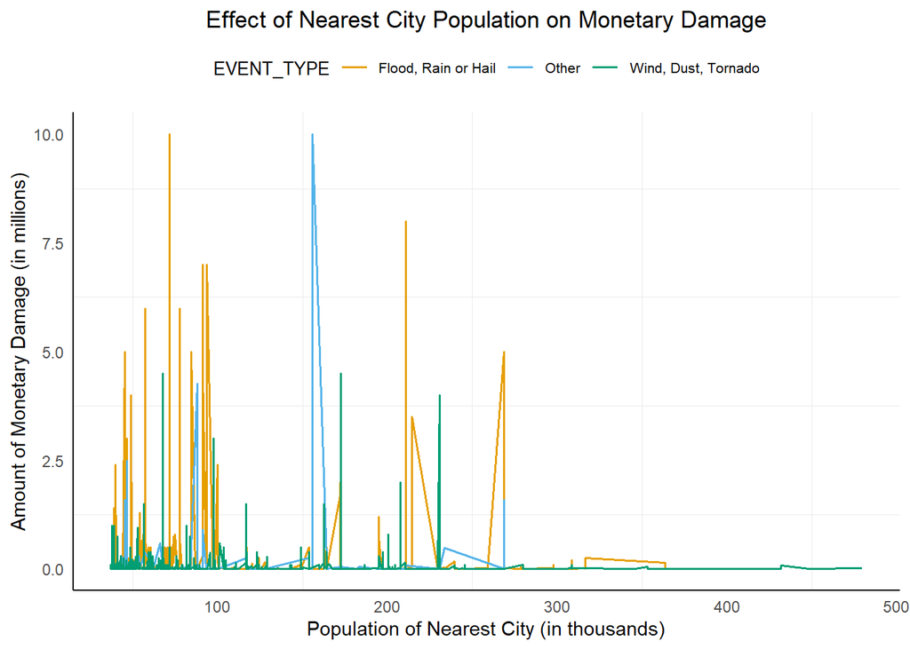

```r
#TEXT: In the above chart, we didn't see much of a clear trend. It does look like smaller cities (under a
#quarter million in population) tend to have the most "spikes" around 5-10 million dollars in damage.
#Mostly, these seem to be more flood, rain or hail (orange), with the highest damage spike also being
#from this category. I want to see if we can zoom in a bit on these smaller cities and see more
#of a trend.

#Now just looking at cities with less than 0.5 million population
last_filtered_data <- merged_data_money_damage_nonzero[merged_data_money_damage_nonzero$Population < 500000,]
ggplot(data = last_filtered_data, aes(x = Population, y = allmoneydamage, color = EVENT_TYPE)) +
  geom_line(linewidth = .7) +
  scale_color_manual(values = c("#E69F00", "#56B4E9", "#009E73")) +
  labs(x = "Population of Nearest City (in thousands)", y = "Amount of Monetary Damage (in millions)") +  # Reme titles
  theme_minimal() +  #Apply minimal theme
  ggtitle("Effect of Nearest City Population on Monetary Damage") +
  theme(plot.title = element_text(hjust = 0.5)) +
  theme(
    panel.grid.major = element_blank(),  # Remove major gridlines
    axis.line = element_line(color = "black"),  # Set axis line color
    legend.position = "top",  # Position legend at the top
    legend.title = element_text(size = 10),  # Set legend title size
    legend.text = element_text(size = 8)  # Set legend text size
  ) +
  scale_x_continuous(labels = scales::comma_format(scale = 1e-3)) +
  scale_y_continuous(labels = scales::comma_format(scale = 1e-6))
```

Still no real clear trend here, although orange (flood, rain, or hail) still seem to most frequently be the cause of significant monetary damage (with one large damage event being from the “other” category). We still see that the cluster of higher monetary damage spikes is towards the smaller population size end of the graph (left) so maybe smaller cities generally have less advanced infrastructure and funding to sufficiently prepare for the consequences of extreme weather events, result in more frequent high-cost damage.